# Chapter 13 - Hotel Bookings

For this chapter, since I did some logistic regression in Python for Kaggle, lets try Rstan !

```r
# Load packages
library(bayesrules)
library(rstanarm)
```

```r
library(bayesplot)
library(tidyverse)
library(tidybayes)
library(broom.mixed)
```

```r
data("hotel_bookings")
```

## Exercise 13.6

### Proportion of the sample bookings were cancelled?

```r
hotel_bookings %>%
   select(is_canceled)  %>% summarize(fraction_cancelled = mean(is_canceled==1))
```

```
## # A tibble: 1 × 1
##   fraction_cancelled
##                <dbl>
## 1              0.366
```

### Look at plots of each predictor vs `is_canceled`

The predictors the problem are `lead time` `previous_cancellations` `is_repeated_guest` and `average_daily_rate`

```r
hotel_bookings <- hotel_bookings %>%
   select(is_canceled,lead_time, previous_cancellations, is_repeated_guest, average_daily_rate )
```

Average valuesa and max values are of interest:

```r
hotel_bookings %>% summarise(across(where(is.numeric), mean))
```

```
## # A tibble: 1 × 4
##   lead_time previous_cancellations is_repeated_guest average_daily_rate
##       <dbl>                  <dbl>             <dbl>              <dbl>
## 1      105.                  0.103             0.032               101.
```

```r
hotel_bookings %>% summarise(across(where(is.numeric), max))
```

```
## # A tibble: 1 × 4
##   lead_time previous_cancellations is_repeated_guest average_daily_rate
##       <dbl>                  <dbl>             <dbl>              <dbl>
## 1       542                     26                 1                304
```

```r
hotel_bookings %>% group_by(is_repeated_guest) %>%
  summarize(cancel_rate = mean(is_canceled==1))
```

```
## # A tibble: 2 × 2
##   is_repeated_guest cancel_rate
##               <dbl>       <dbl>
## 1                 0       0.371
## 2                 1       0.219
```

Looks like repeated guests are less likely to cancel (makes sense)

For the others, we will need to make some cuts to bin the quantitative variables:

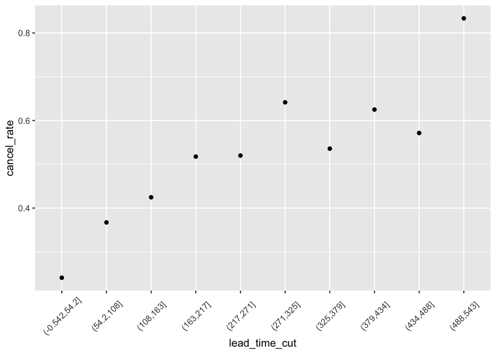

```r
hotel_bookings %>%
  mutate(lead_time_cut = cut(lead_time, breaks =10)) %>%
   group_by(lead_time_cut) %>% summarize(cancel_rate = mean(is_canceled==1)) %>%
  ggplot(aes(x= lead_time_cut, y= cancel_rate)) +
    geom_point() +
    theme(axis.text.x = element_text(angle=45, vjust =0.5))
```

Longer lead times lead to more cancellations

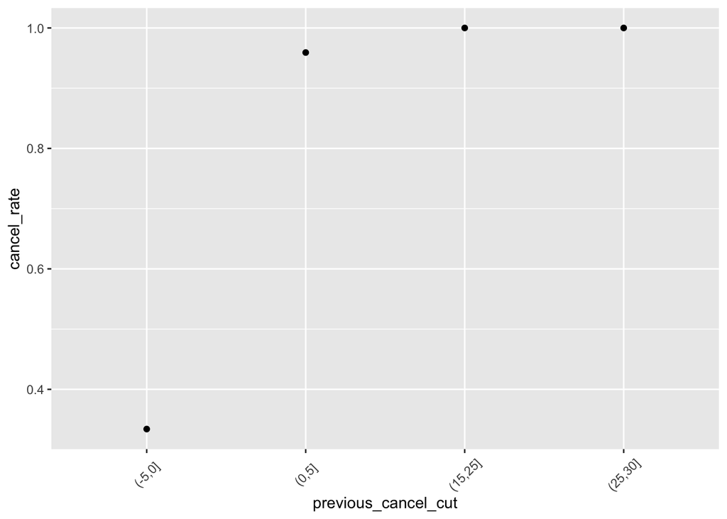

```r
hotel_bookings %>%
  mutate(previous_cancel_cut = cut(previous_cancellations, breaks = c(-5,0,5,10,15,25,30))) %>%
   group_by(previous_cancel_cut) %>% summarize(cancel_rate = mean(is_canceled==1)) %>%
  ggplot(aes(x= previous_cancel_cut, y= cancel_rate)) +
    geom_point() +
    theme(axis.text.x = element_text(angle=45, vjust =0.5))
```

Previously cancelling many times is a very strong predictor.

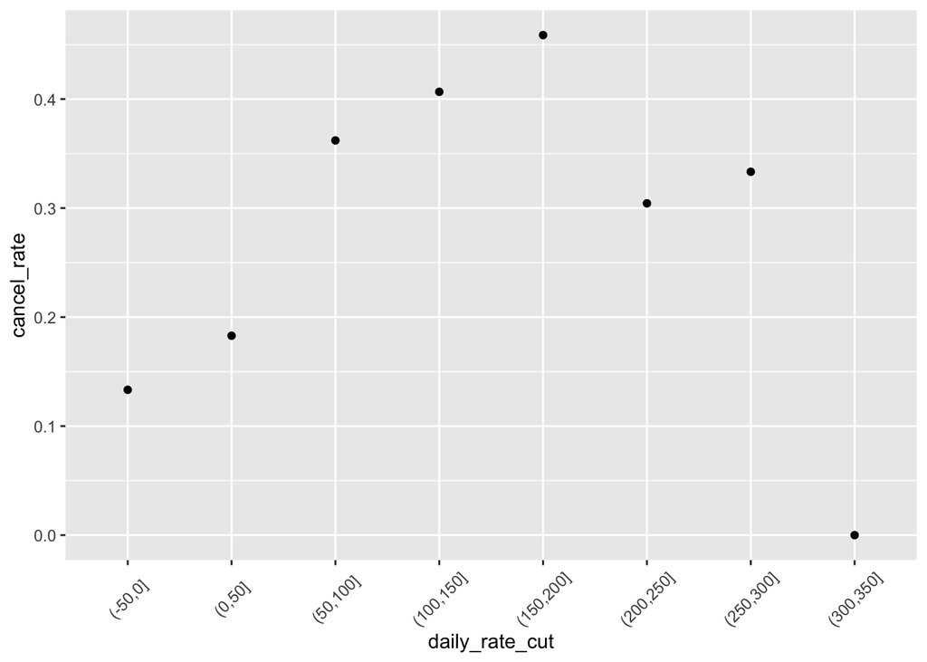

```r
hotel_bookings %>%
  mutate(daily_rate_cut = cut(average_daily_rate, breaks = seq(-50,400,50))) %>%
   group_by(daily_rate_cut) %>% summarize(cancel_rate = mean(is_canceled==1)) %>%
  ggplot(aes(x= daily_rate_cut, y= cancel_rate)) +
    geom_point() +
    theme(axis.text.x = element_text(angle=45, vjust =0.5))
```

Weak predictor, but higher rates lead to more cancellations (except for the very high!) Note the odd ‘free’ hotels.

```r
hotel_bookings %>%
  mutate(daily_rate_cut = cut(average_daily_rate, breaks = seq(-50,400,50))) %>%
   group_by(daily_rate_cut) %>% count
```

```
## # A tibble: 8 × 2
## # Groups:   daily_rate_cut [8]
##   daily_rate_cut     n
##   <fct>          <int>
## 1 (-50,0]           15
## 2 (0,50]            82
## 3 (50,100]         464
## 4 (100,150]        300
## 5 (150,200]        109
## 6 (200,250]         23
## 7 (250,300]          6
## 8 (300,350]          1
```

### Model choice

For the model we will use `is_cancelled ~ lead_time + previous_cancellations + is_repeated_guest + average_daily_rate` with Binomial family and default logit link.

I will use weakly informative priors centered at zero, including for the centered intercept.

## Exercise 13.7

### Simulation of posterior

```r
cancel_model <- stan_glm(is_canceled ~ lead_time + previous_cancellations + is_repeated_guest + average_daily_rate,
                             data = hotel_bookings, family = binomial,
                             prior_intercept = normal(0,1,autoscale=TRUE),
                             prior = normal(0,1, autoscale=TRUE),
                             chains = 4, iter = 5000*2, seed = 84735 )
prior_summary(cancel_model)
```

```
## Priors for model 'cancel_model'
## ------
## Intercept (after predictors centered)
##  ~ normal(location = 0, scale = 1)
##
## Coefficients
##   Specified prior:
##     ~ normal(location = [0,0,0,...], scale = [1,1,1,...])
##   Adjusted prior:
##     ~ normal(location = [0,0,0,...], scale = [0.0094,0.8588,5.6790,...])
## ------
## See help('prior_summary.stanreg') for more details
```

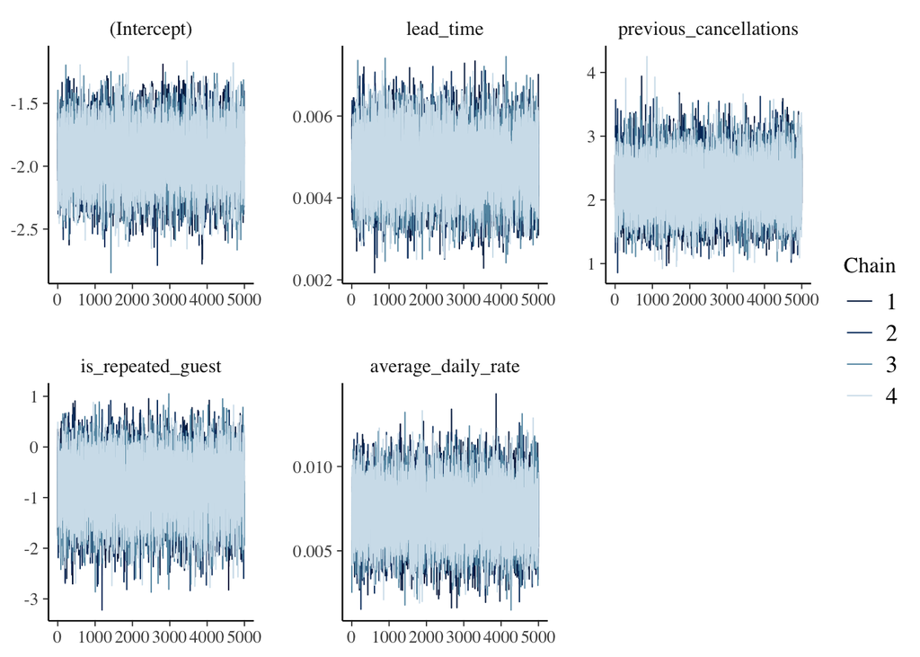

```r
mcmc_trace(cancel_model)
```

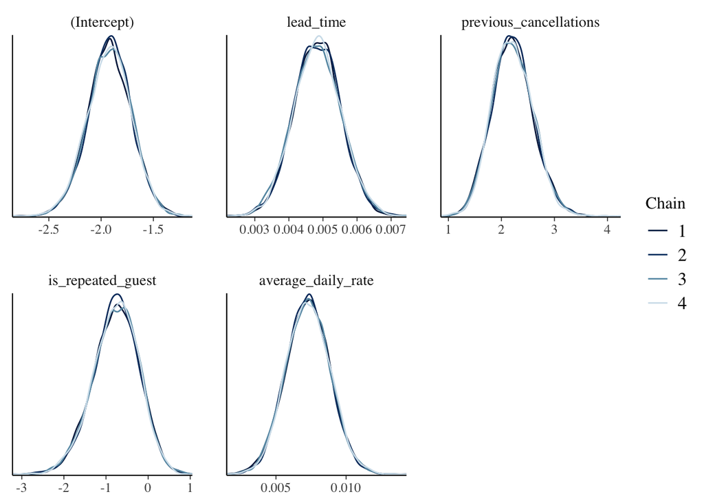

```r
mcmc_dens_overlay(cancel_model)
```

### Model check (PP check)

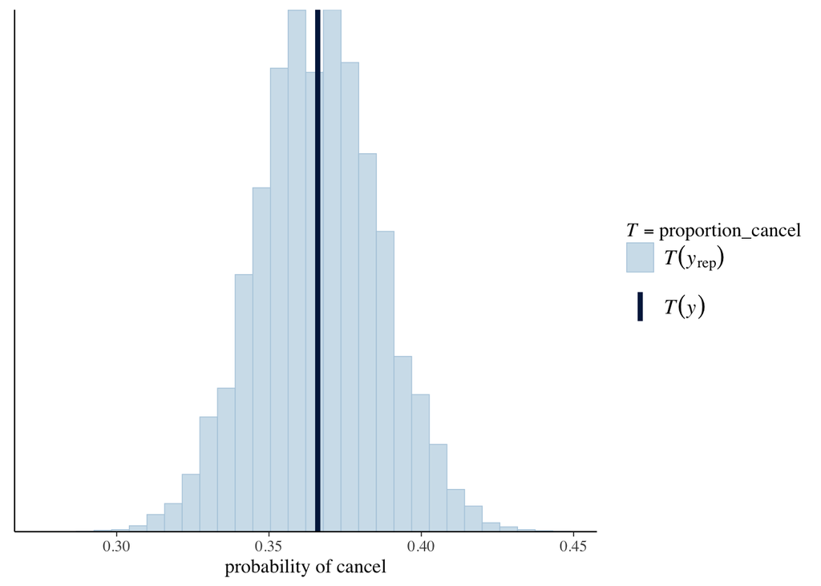

```r
proportion_cancel <- function(x){mean(x == 1)}

pp_check(cancel_model, nreps = 100,
         plotfun = "stat", stat = "proportion_cancel") +
  xlab("probability of cancel")
```

Looks good. Now lets look at the model

### Parameter posteriors

```r
tidy(cancel_model, effects = "fixed", conf.int = TRUE, conf.level = 0.80)
```

```
## # A tibble: 5 × 5
##   term                   estimate std.error conf.low conf.high
##   <chr>                     <dbl>     <dbl>    <dbl>     <dbl>
## 1 (Intercept)            -1.92     0.206    -2.19     -1.65
## 2 lead_time               0.00483  0.000695  0.00394   0.00572
## 3 previous_cancellations  2.20     0.388     1.72      2.71
## 4 is_repeated_guest      -0.743    0.544    -1.47     -0.0869
## 5 average_daily_rate      0.00727  0.00157   0.00527   0.00927
```

The model is simply the logit of the linear model described above, not going to write it down though.

Note that these are log odds. to get odds;

```r
exp(posterior_interval(cancel_model,prob=.8))
```

```
##                              10%        90%
## (Intercept)            0.1120760  0.1912958
## lead_time              1.0039518  1.0057400
## previous_cancellations 5.5973489 15.0516105
## is_repeated_guest      0.2291297  0.9167900
## average_daily_rate     1.0052885  1.0093161
```

Looks to me that all except perhaps `is_repeated_guest` are statistically significant.

For lead time , each 10 days of lead time will cause about a 5% increase in odds of cancelling , so is not very strong For previous cancellations, it is clear that having multiple previous cancellations is storng. For repeated_guest, being repeat guest means the odds are decreased by about half. Finally every 10 dollar increase in rate causes an increats of about 7% as well in the odds, so not very strong there either.

## Exercise 13.8

### Accuracy

First using the `bayesrules` shortcut:

```r
classification_summary(model = cancel_model, data= hotel_bookings, cutoff = 0.5)$confusion_matrix
```

```
##  y   0   1
##  0 574  60
##  1 252 114
```

Lets do it by hand:

```r
cancel_pred <- posterior_predict(cancel_model)
dim(cancel_pred)
```

```
## [1] 20000  1000
```

`cancel_pred` contains 20000 predictions for each data point in the original data. We now compute the p value fore ach one

```r
cancel_classifications <- hotel_bookings %>%
  mutate(cancel_prob = colMeans(cancel_pred),
         cancel_class = as.numeric(cancel_prob >= 0.5),
         match = cancel_class == is_canceled)
```

```r
cancel_classifications  %>%
  group_by(cancel_class,is_canceled) %>% count %>% pivot_wider(names_from=is_canceled,values_from=n)
```

```
## # A tibble: 2 × 3
## # Groups:   cancel_class [2]
##   cancel_class   `0`   `1`
##          <dbl> <int> <int>
## 1            0   574   250
## 2            1    60   116
```

This gives the confusion matrix using the best of my abilities in R at the moment ;). The book uses `table`, which is perhaps easier.

Overall prediction accuracy with 50% cut off:

```r
mean(cancel_classifications$match)
```

```
## [1] 0.69
```

Cross validation:

```r
cv_accuracy <- classification_summary_cv(
  model = cancel_model, data = hotel_bookings, cutoff = 0.5, k = 10)
```

```r
cv_accuracy$cv
```

```
##   sensitivity specificity overall_accuracy
## 1   0.2974036   0.9010455             0.68
```

Accuracy basically matches, so we are not overfitting by this metric.

### Achieve 75% sensitivity.

We would like a sensitivity of 75%. What cutoff will do that, and what is the specificity? By trial and error I find 0.3 works well enough:

```r
classification_summary(model = cancel_model, data= hotel_bookings, cutoff = 0.3)$accuracy_rates
```

```
##
## sensitivity      0.7759563
## specificity      0.5157729
## overall_accuracy 0.6110000
```

Check cv:

```r
cv_accuracy <- classification_summary_cv(
  model = cancel_model, data = hotel_bookings, cutoff = 0.3, k = 10)
```

```r
cv_accuracy$cv
```

```
##   sensitivity specificity overall_accuracy
## 1   0.7807134   0.5184209            0.614
```

## Exercise 13.9

A guest that is new to a hotel and has only canceled a booking 1 time before, has booked a $100 per day hotel room 30 days in advance. Simulate, plot, and discuss the posterior predictive model of Y, whether or not the guest will cancel this booking.

```r
cancel_guest <- posterior_predict(cancel_model, newdata = data.frame(previous_cancellations = c(1),
                                                                     is_repeated_guest=c(0), average_daily_rate=c(100),
                                                                     lead_time= c(30)))
dim(cancel_guest)
```

```
## [1] 20000     1
```

```r
mean(cancel_guest)
```

```
## [1] 0.7508
```

We can do this directly with the model rather then posterior predict:

```r
customer_model <- as.data.frame(cancel_model) %>%
  mutate(log_odds = `(Intercept)` + previous_cancellations*1 + average_daily_rate*100 + lead_time*30,
         odds = exp(log_odds),
         prob = odds / (1 + odds),
         Y = rbinom(20000, size = 1, prob = prob))
```

```r
mean(customer_model$prob)
```

```
## [1] 0.7548094
```

Or using Y

```r
mean(customer_model$Y)
```

```
## [1] 0.75625
```

Note that $\bar{Y} = \Sigma p P(p) = \bar{p}$ so we expect these to be the same within statistical accuracy.